# Reproducible Research: Peer Assessment 1

## Load Packages

Simply load in the packeges I prefer using.

```r
library("dplyr", lib.loc="~/R/win-library/3.1")
```

```r
library("ggplot2", lib.loc="~/R/win-library/3.1")
```

## Loading and preprocessing the data

This asumes the file contaning the data is in the working directry and that the data is in a folder called “activity.csv”

```r
activity<-read.csv(file = "activity.csv")
activity[[2]]<-as.Date(activity[[2]],"%Y-%m-%d")
str(activity)
```

```
## 'data.frame':    17568 obs. of  3 variables:
##  $ steps   : int  NA NA NA NA NA NA NA NA NA NA ...
##  $ date    : Date, format: "2012-10-01" "2012-10-01" ...
##  $ interval: int  0 5 10 15 20 25 30 35 40 45 ...
```

## What is mean total number of steps taken per day?

### 1 Calculate the total number of steps taken per day

```r
activity_by_date<-group_by(activity,date)
steps_per_day<-summarise(activity_by_date,steps=sum(steps))
print(steps_per_day)
```

```
## Source: local data frame [61 x 2]
##
##          date steps
## 1  2012-10-01    NA
## 2  2012-10-02   126
## 3  2012-10-03 11352
## 4  2012-10-04 12116
## 5  2012-10-05 13294
## 6  2012-10-06 15420
## 7  2012-10-07 11015
## 8  2012-10-08    NA
## 9  2012-10-09 12811
## 10 2012-10-10  9900
## ..        ...   ...
```

### 2 Make a histogram of the total number of steps taken each day

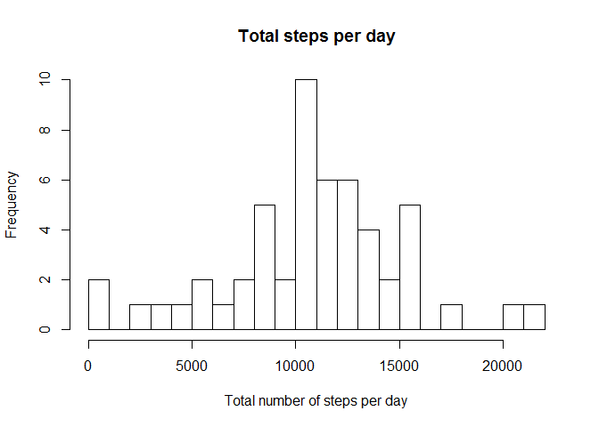

```r
hist(steps_per_day[[2]],breaks = 20,xlab = "Total number of steps per day",main = "Total steps per day")
```

### 3 Calculate and report the mean and median of the total number of steps taken per day.

```r
mean<-mean(steps_per_day[[2]],na.rm = T)
median<-median(steps_per_day[[2]],na.rm = T)
```

## What is the average daily activity pattern?

### 1 Make a time series plot of steps and time interval

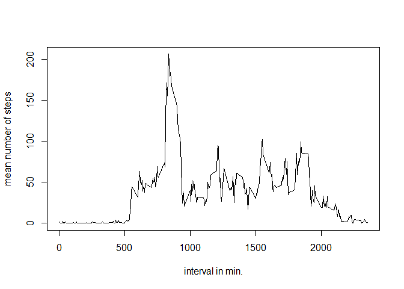

```r
activity_by_interval<-group_by(activity,interval)
steps_per_interval<-summarise(activity_by_interval,steps=mean(steps,na.rm = TRUE))
with(steps_per_interval,plot(x = interval,y = steps,type = "l",xlab = "interval in min.",ylab = "mean number of steps"))
```

### 2 Which 5-minute interval, on average across all the days in the dataset, contains the maximum number of steps

```r
filter(steps_per_interval,steps==max(steps))
```

```
## Source: local data frame [1 x 2]
##
##   interval    steps
## 1      835 206.1698
```

## Imputing missing values

### 1 Calculate and report the total number of missing values in the dataset

```r
sum(is.na(activity))
```

```
## [1] 2304
```

### 2 & 3 Devise a strategy for filling in all of the missing values in the dataset and creat a new data set.

I combind thease two steps as it was easior to rite the code and think about the problem (or at least it was for me).

```r
activity_na<-activity

for(i in 1:nrow(activity_na)){
  if(is.na(activity_na[i,1])==TRUE){
    activity_na[i,1]<-as.integer(filter(steps_per_interval,interval==activity_na[i,3])[1,2])
  }
}

head(activity_na)
```

```
##   steps       date interval
## 1     1 2012-10-01        0
## 2     0 2012-10-01        5
## 3     0 2012-10-01       10
## 4     0 2012-10-01       15
## 5     0 2012-10-01       20
## 6     2 2012-10-01       25
```

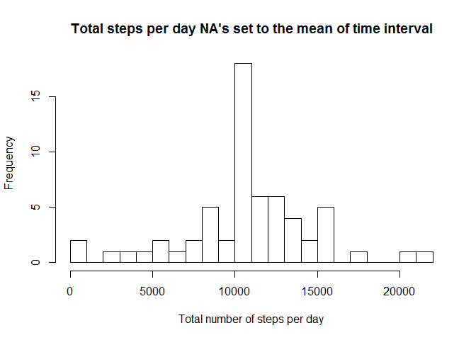

```r
activity_by_date_na<-group_by(activity_na,date)
steps_per_day_na<-summarise(activity_by_date_na,steps=sum(steps))
hist(steps_per_day_na[[2]],breaks = 20,xlab = "Total number of steps per day",main = "Total steps per day NA's set to the mean of time interval")
```

```r
mean<-mean(steps_per_day_na[[2]])
median<-median(steps_per_day_na[[2]])
```

## Are there differences in activity patterns between weekdays and weekends?

### 1 Create a new factor variable in the dataset indicating whether a given date is a weekday or weekend day

```r
activity_na<-mutate(activity_na,day=factor(weekdays(date)))

weekend<-c("Saturday","Sunday")

activity_na<-mutate(activity_na,day=factor(day %in% weekend,levels=c(F,T),labels=c("weekday","weekend")))
head(activity_na)
```

```
##   steps       date interval     day
## 1     1 2012-10-01        0 weekday
## 2     0 2012-10-01        5 weekday
## 3     0 2012-10-01       10 weekday
## 4     0 2012-10-01       15 weekday
## 5     0 2012-10-01       20 weekday
## 6     2 2012-10-01       25 weekday
```

### 2 Make a panel plot containing a time series plot of interval vs the mean number of steps sorted by weekday/end

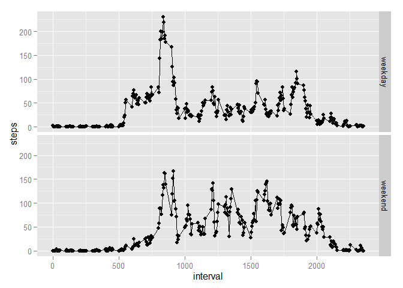

```r
activity_by_interval_na<-group_by(activity_na,interval,day)
steps_per_interval_na<-summarise(activity_by_interval_na,steps=mean(steps,na.rm = TRUE))
g<-qplot(x=interval,y=steps,data=steps_per_interval_na,facets = day~. )
 g+geom_line()
```